# Proyecto Modulo 2 - Parte 3. Calidad del café

Authors

Becerra Ayala Anay

Diaz Cuevas Bruno

Patiño Gonzalez Brandon

Olvera Galeana Enrique

David Suarez Lopez

# Actividad de coffe_ratings.csv

En esta actividad se hará un análisis exploratorio y limpieza de datos con las tabla de coffee_ratings.csv, dicha tabla tiene información de peso, humedad, altitutd, nombre de granja y etc, siendo información necesaria en la producción de café.

## Actividades 0, 1 y 2

```r
#1
install.packages("reticulate")
install.packages("dplyr")
install.packages("ggplot2")
```

## Análisis de valores faltantes

Primero, haremos la instalación de pandas para poder trabajar dataframes con R usando comando de python. Esto lo podemos hacer debido a la instalación de “reticulate”:

```r
#2
#en esta sección llamamos nuestras librerias
library(reticulate) #nos permite programar en python usando r
library(dplyr) #nos permite trabajar dataframe en comando r
library(ggplot2) #nos permite hacer graficas en r
```

```r
#3
pd <- py_require("pandas") #instalamos panda en python
#esto nos ayuda a generar los dataframe en python con R
```

```r
#4
library(reticulate) #siempre se llama reticulate para correr codigo de python
pd <- import("pandas") #pedimos importar la librería de pandas de python
coffee <- pd$read_csv("coffee_ratings.csv")%>% py_to_r() #hacemos lectura de los datos de coffeee
glimpse(coffee) #pedimos que nos muestre una especie de data frame sobre los datos café
```

```
Rows: 1,339
Columns: 43
$ total_cup_points      <dbl> 90.58, 89.92, 89.75, 89.00, 88.83, 88.83, 88.75,…
$ species               <chr> "Arabica", "Arabica", "Arabica", "Arabica", "Ara…
$ owner                 <chr> "metad plc", "metad plc", "grounds for health ad…
$ country_of_origin     <chr> "Ethiopia", "Ethiopia", "Guatemala", "Ethiopia",…
$ farm_name             <chr> "metad plc", "metad plc", "san marcos barrancas …
$ lot_number            <chr> NA, NA, NA, NA, NA, NA, NA, NA, NA, NA, NA, NA, …
$ mill                  <chr> "metad plc", "metad plc", NA, "wolensu", "metad …
$ ico_number            <chr> "2014/2015", "2014/2015", NA, NA, "2014/2015", N…
$ company               <chr> "metad agricultural developmet plc", "metad agri…
$ altitude              <chr> "1950-2200", "1950-2200", "1600 - 1800 m", "1800…
$ region                <chr> "guji-hambela", "guji-hambela", NA, "oromia", "g…
$ producer              <chr> "METAD PLC", "METAD PLC", NA, "Yidnekachew Dabes…
$ number_of_bags        <dbl> 300, 300, 5, 320, 300, 100, 100, 300, 300, 50, 3…
```

[output cut: 30 more lines]

```r
#5
library(readr)
```

```r
#6
#usando dplyr para programar en r y hacer vista del dataframe
coffee <- read_csv("coffee_ratings.csv")
glimpse(coffee) #esto nos arroja el data frame con los valores de la columna de forma desordenada
```

```
Rows: 1,339
Columns: 43
$ total_cup_points      <dbl> 90.58, 89.92, 89.75, 89.00, 88.83, 88.83, 88.75,…
$ species               <chr> "Arabica", "Arabica", "Arabica", "Arabica", "Ara…
$ owner                 <chr> "metad plc", "metad plc", "grounds for health ad…
$ country_of_origin     <chr> "Ethiopia", "Ethiopia", "Guatemala", "Ethiopia",…
$ farm_name             <chr> "metad plc", "metad plc", "san marcos barrancas …
$ lot_number            <chr> NA, NA, NA, NA, NA, NA, NA, NA, NA, NA, NA, NA, …
$ mill                  <chr> "metad plc", "metad plc", NA, "wolensu", "metad …
$ ico_number            <chr> "2014/2015", "2014/2015", NA, NA, "2014/2015", N…
$ company               <chr> "metad agricultural developmet plc", "metad agri…
$ altitude              <chr> "1950-2200", "1950-2200", "1600 - 1800 m", "1800…
$ region                <chr> "guji-hambela", "guji-hambela", NA, "oromia", "g…
$ producer              <chr> "METAD PLC", "METAD PLC", NA, "Yidnekachew Dabes…
$ number_of_bags        <dbl> 300, 300, 5, 320, 300, 100, 100, 300, 300, 50, 3…
```

[output cut: 30 more lines]

En el data frame vemos que son $43$ columnas que nos da información sobre total_cup_points (calidad de la taza de café), species (especie de café), owner (propietario del cultivo de café), country_of_origin (país de origen del café), altitude_mean_meters (altura promedio en metros) y etc, así como se muestra en la impresión de nombres de columnas con reticulate.

```r
#7
df <- read_csv("coffee_ratings.csv")
df %>%
  names() %>%
  print()
```

```
 [1] "total_cup_points"      "species"               "owner"
 [4] "country_of_origin"     "farm_name"             "lot_number"
 [7] "mill"                  "ico_number"            "company"
[10] "altitude"              "region"                "producer"
[13] "number_of_bags"        "bag_weight"            "in_country_partner"
[16] "harvest_year"          "grading_date"          "owner_1"
[19] "variety"               "processing_method"     "aroma"
[22] "flavor"                "aftertaste"            "acidity"
[25] "body"                  "balance"               "uniformity"
[28] "clean_cup"             "sweetness"             "cupper_points"
[31] "moisture"              "category_one_defects"  "quakers"
[34] "color"                 "category_two_defects"  "expiration"
[37] "certification_body"    "certification_address" "certification_contact"
[40] "unit_of_measurement"   "altitude_low_meters"   "altitude_high_meters"
[43] "altitude_mean_meters"
```

```r
df %>%
  ncol() %>%
  paste("\nTotal:",., "columnas") %>%
  cat()
```

```
Total: 43 columnas
```

```r
#8
library(reticulate)
py_run_string("
import pandas as pd

df = pd.read_csv('coffee_ratings.csv') #pedimos lectura del archivo .csv

print('Nombres de todas las columnas:') #imprime el nombre de las columnas
print(df.columns.tolist()) #nos da los nombres de cada columna o sus strings

print(f'\\nTotal: {len(df.columns)} columnas') #nos dice cuantos strings o atributos del .csv se toman en cuenta
")
```

```
Nombres de todas las columnas:
['total_cup_points', 'species', 'owner', 'country_of_origin', 'farm_name', 'lot_number', 'mill', 'ico_number', 'company', 'altitude', 'region', 'producer', 'number_of_bags', 'bag_weight', 'in_country_partner', 'harvest_year', 'grading_date', 'owner_1', 'variety', 'processing_method', 'aroma', 'flavo…

Total: 43 columnas
```

Con esto conocemos el número total de columnas y lo que deben registrar esas columnas usando python.

Por otro lado, podemos crear un dataframe con reticulate más ordenado y que podamos ver información de los atributos de cada una de sus columnas.

```r
#9
df <- read_csv("coffee_ratings.csv") # lectura directa en R
df # muestra el dataframe
```

```
# A tibble: 1,339 × 43
   total_cup_points species owner   country_of_origin farm_name lot_number mill
              <dbl> <chr>   <chr>   <chr>             <chr>     <chr>      <chr>
 1             90.6 Arabica metad … Ethiopia          "metad p… <NA>       meta…
 2             89.9 Arabica metad … Ethiopia          "metad p… <NA>       meta…
 3             89.8 Arabica ground… Guatemala         "san mar… <NA>       <NA>
 4             89   Arabica yidnek… Ethiopia          "yidneka… <NA>       wole…
 5             88.8 Arabica metad … Ethiopia          "metad p… <NA>       meta…
 6             88.8 Arabica ji-ae … Brazil             <NA>     <NA>       <NA>
 7             88.8 Arabica hugo v… Peru               <NA>     <NA>       hvc
 8             88.7 Arabica ethiop… Ethiopia          "aolme"   <NA>       c.p.…
 9             88.4 Arabica ethiop… Ethiopia          "aolme"   <NA>       c.p.…
10             88.2 Arabica diamon… Ethiopia          "tulla c… <NA>       tull…
# ℹ 1,329 more rows
# ℹ 36 more variables: ico_number <chr>, company <chr>, altitude <chr>,
#   region <chr>, producer <chr>, number_of_bags <dbl>, bag_weight <chr>,
#   in_country_partner <chr>, harvest_year <chr>, grading_date <chr>,
#   owner_1 <chr>, variety <chr>, processing_method <chr>, aroma <dbl>,
#   flavor <dbl>, aftertaste <dbl>, acidity <dbl>, body <dbl>, balance <dbl>,
#   uniformity <dbl>, clean_cup <dbl>, sweetness <dbl>, cupper_points <dbl>, …
```

```r
#10
library(reticulate) #llamamos reticulate para no tener problemas en la lectura con python
pd <- import("pandas") #pedimos importar la librería pandas
df <- pd$read_csv("coffee_ratings.csv") #pedimos que lea el pandas con $ que es el puente entre python y r
head(df) #llamamos al dataframe de ratings cooffee
```

```
  total_cup_points species                    owner country_of_origin
1            90.58 Arabica                metad plc          Ethiopia
2            89.92 Arabica                metad plc          Ethiopia
3            89.75 Arabica grounds for health admin         Guatemala
4            89.00 Arabica      yidnekachew dabessa          Ethiopia
5            88.83 Arabica                metad plc          Ethiopia
6            88.83 Arabica                ji-ae ahn            Brazil
                                 farm_name lot_number      mill ico_number
1                                metad plc       <NA> metad plc  2014/2015
2                                metad plc       <NA> metad plc  2014/2015
3 san marcos barrancas "san cristobal cuch       <NA>      <NA>       <NA>
4    yidnekachew dabessa coffee plantation       <NA>   wolensu       <NA>
5                                metad plc       <NA> metad plc  2014/2015
6                                     <NA>       <NA>      <NA>       <NA>
                                company      altitude       region
```

[output cut: 69 more lines]

```r
#11
install.packages("readr")
```

```r
#12
library(readr) #llamamos la librearia readr para hacer lectura con r del csv
```

```r
#13
datos <- readr::read_csv("coffee_ratings.csv") #pedimos que lea los datos coffee tatings
```

Además, podemos notar que el dataframe creado por pandas tiene NA o valores vacíos, por ello, nos damos a la tarea contar cuantos NA hay en cada atributo de cada una de las columnas. La idea es calcular el total de NA con respecto de los datos tomados. Así, podemos ver si un NA puede ser eliminado.

```r
#14
reticulate::py_run_string("
import pandas as pd
df = pd.read_csv('coffee_ratings.csv')
print(df.isna().sum().sort_values(ascending=False))
")
```

```
lot_number               1063
farm_name                 359
mill                      318
color                     270
producer                  232
altitude_mean_meters      230
altitude_low_meters       230
altitude_high_meters      230
altitude                  226
variety                   226
company                   209
processing_method         170
ico_number                159
region                     59
harvest_year               47
owner_1                     7
owner                       7
country_of_origin           1
quakers                     1
total_cup_points            0
species                     0
flavor                      0
aroma                       0
grading_date                0
in_country_partner          0
number_of_bags              0
bag_weight                  0
uniformity                  0
balance                     0
body                        0
acidity                     0
aftertaste                  0
moisture                    0
clean_cup                   0
sweetness                   0
category_two_defects        0
category_one_defects        0
cupper_points               0
expiration                  0
certification_contact       0
certification_address       0
certification_body          0
unit_of_measurement         0
dtype: int64
```

```r
#15
install.packages("tidyr")
```

```r
#16
library(tidyr)
```

```r
#17
df <- read_csv("coffee_ratings.csv")
df %>%
  summarise(across(everything(), ~ sum(is.na(.)))) %>%
  pivot_longer(everything(), names_to = "columna", values_to = "total_na") %>%
  arrange(desc(total_na))
```

```
# A tibble: 43 × 2
   columna              total_na
   <chr>                   <int>
 1 lot_number               1063
 2 farm_name                 359
 3 mill                      315
 4 producer                  231
 5 altitude_low_meters       230
 6 altitude_high_meters      230
 7 altitude_mean_meters      230
 8 altitude                  226
 9 variety                   226
10 color                     218
# ℹ 33 more rows
```

La idea es visualizar cuantos NA hay por cada columna de la tabla y como esto podría afectar nuestro análisis de datos. Como vemos lot_number, farm_name, color, mill y etc, tienes muchos NA, sin embargo, ¿Cuánto es mucho? Por ende, debemos de ver los NA de forma muy visual y de forma porcentual o de conteo discreto de estos usando mpas de calor.

Consecuentemente, calculamos el porcentaje de NA por cada columna que corresponde a cada uno de los atributos:

```r
#18
library(reticulate) #llamamos a reticulate para ejecutar una orden de python
py_require("seaborn") #usamos el paquete seaborn de python, lo que nos ayuda a graficar de forma más sencilla sin tanto código
```

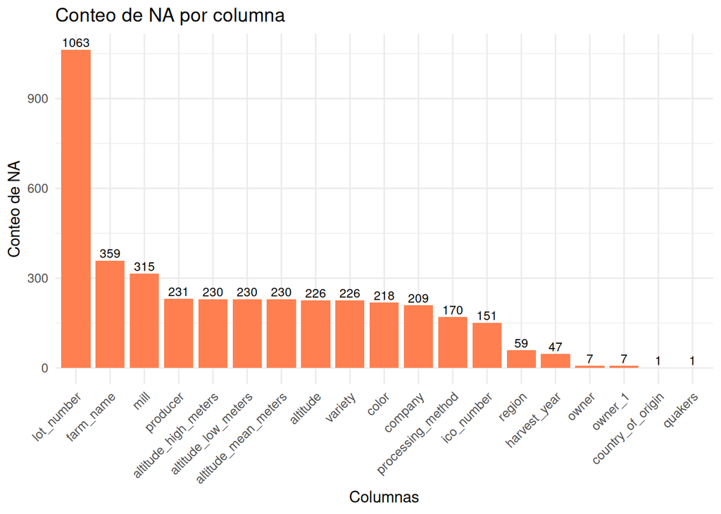

```r
#19
df <- read_csv("coffee_ratings.csv")
df %>%
  summarise(across(everything(), ~ sum(is.na(.)))) %>%
  pivot_longer(everything(), names_to = "columna", values_to = "total_na") %>%
  filter(total_na > 0) %>%
  arrange(desc(total_na)) %>%
  ggplot(aes(x = reorder(columna, -total_na), y = total_na)) +
  geom_col(fill = "coral", width = 0.85) +
  geom_text(aes(label = total_na), vjust = -0.3, size = 3) +
  labs(title = "Conteo de NA por columna",
       x = "Columnas", y = "Conteo de NA") +
  theme_minimal() +
  theme(axis.text.x = element_text(angle = 45, hjust = 1))
```

```r
library(reticulate)

py_run_string("
import matplotlib
matplotlib.use('Agg')
import matplotlib.pyplot as plt
import seaborn as sns
import pandas as pd

df = pd.read_csv('coffee_ratings.csv') # CSV original, sin color2

na_porcenta = (df.isna().sum() / len(df) * 100).sort_values(ascending=False)
cols_con_na = na_porcenta[na_porcenta > 0].index
na_count = df.isna().sum()[cols_con_na]

fig, axes = plt.subplots(2, 1, figsize=(14, 10), gridspec_kw={'height_ratios': [3, 1]})
sns.heatmap(df[cols_con_na].isna(), cbar=False, yticklabels=False,
            cmap='rocket_r', ax=axes[0])
axes[0].set_title('Patrón de Valores Faltantes', fontsize=14)
axes[0].set_xlabel('')
axes[0].set_xticks([])

bars = na_count.plot(kind='bar', ax=axes[1], color='coral', width=0.85)
axes[1].set_ylabel('Conteo de NA')
axes[1].set_xlabel('Columnas')
axes[1].tick_params(axis='x', rotation=45)
axes[1].bar_label(bars.containers[0], fmt='%d', padding=3, fontsize=9)

plt.tight_layout()
plt.show()
")
```

[output not shown]

```r
#21
py_run_string("
import pandas as pd
df = pd.read_csv('coffee_ratings.csv')

filas_completas = df.dropna().shape[0]
total_filas = df.shape[0]
print(f'Filas completas: {filas_completas} de {total_filas}')
print(f'Porcentaje: {filas_completas/total_filas*100:.1f}%')
print(f'Filas con al menos 1 NA: {total_filas - filas_completas}')
")
```

```
Filas completas: 132 de 1339
Porcentaje: 9.9%
Filas con al menos 1 NA: 1207
```

Aquí hacemos un conteo rápido del peso de los NA en el .csv, vemos que las filas completas representan el $9.9\%$ de los datos de nuestra tabla. Por otro lado, vemos que la mayoría de filas tienen muchos NA, lo que puede indicar una mala toma de datos o no hay datos.

```r
#22
df <- read_csv("coffee_ratings.csv") #leeemos el .csv con dataframe
total_filas <- nrow(df) #vemos el número de columnas
filas_completas <- sum(complete.cases(df)) #sumamos todas la columnas completas o sin na

cat("Filas completas:", filas_completas, "de", total_filas, "\n")
```

```
Filas completas: 132 de 1339
```

```r
cat("Porcentaje:", round(filas_completas / total_filas * 100, 1), "%\n")
```

```
Porcentaje: 9.9 %
```

```r
cat("Filas con al menos 1 NA:", total_filas - filas_completas, "\n")
```

```
Filas con al menos 1 NA: 1207
```

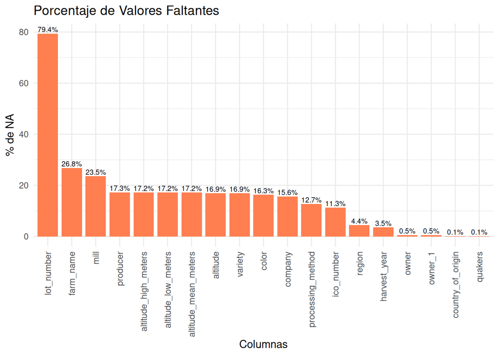

```r
#23
df <- read_csv("coffee_ratings.csv")
df %>%
  summarise(across(everything(), ~ sum(is.na(.)) / n() * 100)) %>%
  pivot_longer(everything(), names_to = "columna", values_to = "pct_na") %>%
  filter(pct_na > 0) %>%
  arrange(desc(pct_na)) %>%
  ggplot(aes(x = reorder(columna, -pct_na), y = pct_na)) +
  geom_col(fill = "coral", width = 0.85) +
  geom_text(aes(label = sprintf("%.1f%%", pct_na)),
            vjust = -0.3, size = 2.5) +
  labs(title = "Porcentaje de Valores Faltantes",
       x = "Columnas", y = "% de NA") +
  theme_minimal() +
  theme(axis.text.x = element_text(angle = 90, hjust = 1, vjust = 0.5))
```

```r
#24
library(reticulate)

py_run_string("
import pandas as pd
import seaborn as sns
import matplotlib.pyplot as plt

df = pd.read_csv('coffee_ratings.csv') #abrimos o leemos el csv con pandas
na_percent = (df.isna().sum() / len(df) * 100).sort_values(ascending=False) #que nos
#arroje el porcentaje de na por columnas
cols_con_na = na_percent[na_percent > 0].index #agrega el valor de porcentaje de #cada columna

fig, axes = plt.subplots(2, 1, figsize=(12, 8), gridspec_kw={'height_ratios': [3, 1]}) #definimos tamaños del gráfico

# hacemos el mapeo de calor arriba de las barras con seanborn
sns.heatmap(df[cols_con_na].isna(), cbar=False, yticklabels=False,
            cmap='rocket_r', ax=axes[0])
axes[0].set_title('Porcentaje de Valores Faltantes', fontsize=14)
axes[0].set_xlabel('')
axes[0].set_xticks([])

# Barra con % abajo
bars = na_percent[cols_con_na].plot(kind='bar', ax=axes[1], color='coral')
axes[1].set_ylabel('% de NA')
axes[1].set_xlabel('Columnas')
axes[1].tick_params(axis='x', rotation=90)

# Agrega los números arriba de cada barra
axes[1].bar_label(bars.containers[0], fmt='%.1f%%', padding=3, fontsize=7)

plt.tight_layout()
plt.show()
")
```

Por ende, lo que nos corresponde es analizar si hay relación entre los NA y esas coincidencias porcentuales en la captura de datos del coffeee_ratings.csv. Por ende, a continuación hacemos un mapero de correlación entre los valores de las filas:

```r
#25
install.packages("corrplot")
```

```r
#26
library(corrplot) #usamos la librería de correlación, para ahorrar pasos en ggplot2
```

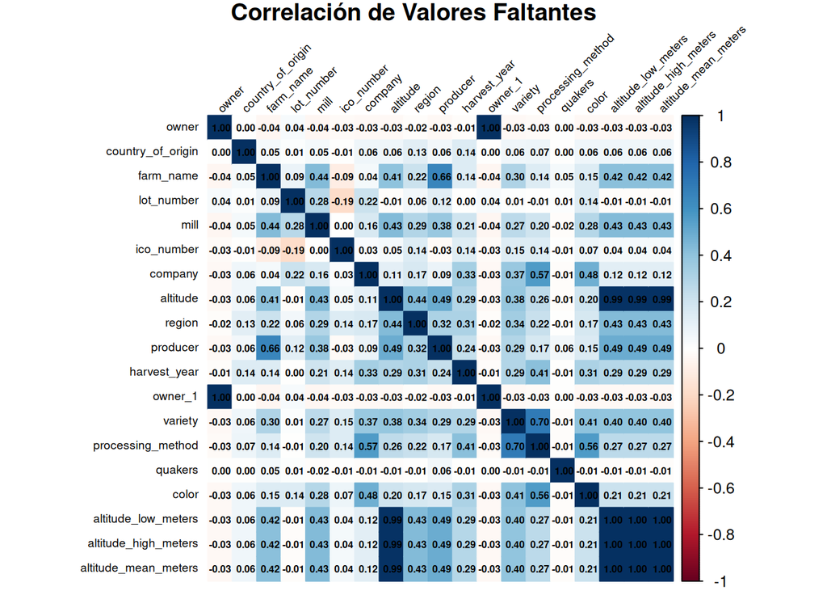

```r
#27
df %>%
  select(where(~ any(is.na(.)))) %>% #seleccionamos todos los na
  mutate(across(everything(), is.na)) %>% #los mutamos a objetos contables
  cor() %>%
  corrplot(method = "color", #pedimos la gráfica de correlación con todos las especificaciones
           col = COL2('RdBu', 200),
           tl.col = "black", tl.srt = 45, tl.cex = 0.6,
           addCoef.col = "black", number.cex = 0.5,
           title = "Correlación de Valores Faltantes", #titulo del gráfico
           mar = c(0,0,1,0)) #controla el margen del grafico
```

```r
#28
library(reticulate)
py_run_string("
import pandas as pd
import seaborn as sns
import matplotlib.pyplot as plt

df = pd.read_csv('coffee_ratings.csv') #leemos el df en pandas
cols_con_na = df.columns[df.isna().any()] #que tome los valores con na

plt.figure(figsize=(9, 5)) # tamaño de la imagen
sns.heatmap(df[cols_con_na].isna().corr(),
            cmap='coolwarm',
            annot=True,
            fmt='.2f',
            vmin=-1, vmax=1,
            annot_kws={'size': 6}) # Fuente más chica
plt.title('Correlación de Valores Faltantes', fontsize=10)
plt.xticks(rotation=45, ha='right',fontsize=6)
plt.yticks(rotation=0,fontsize=6)
plt.tight_layout()
plt.show()
")
```

En efecto, esto confirma nuestras sospecha, los valores de altitud tiene una correlación muy alta, es decir que tomaron los mismos datos y otros no los concían, coincidiendo punto a punto. Por otro lado, owner y owner_1, tienen un correlación alta, quiere decir que replicaron las filas en ambas columnas. Es obvio que la traza de la matriz debe coincidir con sus mismos valores, y los de correlación media-alta como farm_name y producer coinciden en $0.66$, lo que puede indicar que se pusiera el mismo dato para el llenado de la tabla. Otro más o menos interesante, es que se puede ver el desconocimiento del proceso de producción con la variedad, lo que indica que no se supo llenar o se desconoce por parte de los entrevistados productores de café.

Finalmnete, otro análisis que vale la pena hacer para los NA es ver que países reportan más NA y cuáles columnas les falla más a cada uno.

```r
#29
df %>%
  group_by(country_of_origin) %>%
  summarise(
    total_cafes = n(),
    cafes_con_na = sum(if_any(everything(), is.na)),
    .groups = "drop"
  ) %>%
  mutate(porcent_con_na = round(cafes_con_na / total_cafes * 100, 1)) %>%
  arrange(desc(porcent_con_na))
```

```
# A tibble: 37 × 4
   country_of_origin total_cafes cafes_con_na porcent_con_na
   <chr>                   <int>        <int>          <dbl>
 1 Burundi                     2            2            100
 2 Colombia                  183          183            100
 3 Cote d?Ivoire               1            1            100
 4 Ecuador                     3            3            100
 5 Ethiopia                   44           44            100
 6 Haiti                       6            6            100
 7 Japan                       1            1            100
 8 Kenya                      25           25            100
 9 Laos                        3            3            100
10 Malawi                     11           11            100
# ℹ 27 more rows
```

```r
#30
py_run_string("
import pandas as pd

df = pd.read_csv('coffee_ratings.csv') #leemos con pandas el csv

# marcamos filas que tienen al menos un na
df['tiene_na'] = df.isna().any(axis=1)

resultado = df.groupby('country_of_origin').agg(
    total_cafes=('tiene_na', 'count'),
    cafes_con_na=('tiene_na', 'sum')
)
resultado['%_con_na'] = (resultado['cafes_con_na'] / resultado['total_cafes'] * 100).round(1) #sacamos el porcentaje de na de la columna na por país
resultado = resultado.sort_values('%_con_na', ascending=False) #que acomode el pctj o porcentaje de mayor a menor

print('Países con mayor % de cafés incompletos:') #imprime los países con mayor café incompletp
print(resultado.head(20)) #pedimos al menos 20 filas
")
```

```
Países con mayor % de cafés incompletos:
                   total_cafes  cafes_con_na  %_con_na
country_of_origin
Burundi                      2             2     100.0
Colombia                   183           183     100.0
Ecuador                      3             3     100.0
Cote d?Ivoire                1             1     100.0
Vietnam                      8             8     100.0
Zambia                       1             1     100.0
Haiti                        6             6     100.0
Ethiopia                    44            44     100.0
Laos                         3             3     100.0
Malawi                      11            11     100.0
Japan                        1             1     100.0
Kenya                       25            25     100.0
Mauritius                    1             1     100.0
United States               10            10     100.0
Philippines                  5             5     100.0
Rwanda                       1             1     100.0
Peru                        10            10     100.0
Papua New Guinea             1             1     100.0
Panama                       4             4     100.0
Myanmar                      8             8     100.0
```

```r
#31
df <- read_csv("coffee_ratings.csv")
# países con más 30 cafés
paises_grandes <- df %>%
  count(country_of_origin) %>%
  filter(n >= 30) %>%
  pull(country_of_origin) %>%
  head(6)  # pedimos 6 países
#aplicamos un filtro por países con más na
for (pais in paises_grandes) {
  df_pais <- df %>% filter(country_of_origin == pais)

  na_cols <- df_pais %>% #filtramos las columnas con na
    summarise(across(everything(), ~ sum(is.na(.)))) %>%
    pivot_longer(everything(), names_to = "columna", values_to = "total_na") %>%
    filter(total_na > 0) %>% #pedimos aquellas con aunque sea un na
    arrange(desc(total_na)) %>%
    head(6)  # 6 columnas con más NA

  cat("\n=== ", pais, " === ", nrow(df_pais), " cafés\n", sep = "")
  print(na_cols, n = Inf)
}
```

```
=== Brazil === 132 cafés
# A tibble: 6 × 2
  columna              total_na
  <chr>                   <int>
1 lot_number                 90
2 mill                       42
3 altitude_low_meters        27
4 altitude_high_meters       27
5 altitude_mean_meters       27
6 altitude                   25

=== Colombia === 183 cafés
# A tibble: 6 × 2
  columna    total_na
  <chr>         <int>
1 farm_name       167
2 lot_number      150
3 producer         90
4 mill             60
5 color            48
6 variety          42

=== Costa Rica === 51 cafés
# A tibble: 6 × 2
  columna    total_na
  <chr>         <int>
1 lot_number       35
2 farm_name         8
3 ico_number        7
4 producer          6
5 variety           6
6 mill              5

=== Ethiopia === 44 cafés
# A tibble: 6 × 2
  columna           total_na
  <chr>                <int>
1 lot_number              40
2 variety                 29
3 color                   26
```

[output cut: 10 more lines]

```
3 altitude_low_meters        25
4 altitude_high_meters       25
5 altitude_mean_meters       25
6 mill                       14

=== Honduras === 53 cafés
# A tibble: 6 × 2
  columna           total_na
  <chr>                <int>
1 lot_number              30
2 owner                    6
3 owner_1                  6
4 processing_method        4
5 mill                     3
6 variety                  3
```

```r
#32
py_run_string("
import pandas as pd

df = pd.read_csv('coffee_ratings.csv')

# países con más 30 cafés para ver más errores
paises_grandes = df['country_of_origin'].value_counts()
paises_grandes = paises_grandes[paises_grandes >= 30].index

for pais in paises_grandes[:6]:  # pedimos 6 países
    df_pais = df[df['country_of_origin'] == pais] #pedimos el nombre de cada país dentro de los 6 en el top
    na_cols = df_pais.isna().sum() #hacemos el conteo de NA por columna
    na_cols = na_cols[na_cols > 0].sort_values(ascending=False) #que acomode los valores de form ascendente

    print(f'\\n=== {pais} === {len(df_pais)} cafés')
    print(na_cols.head(6)) #imprime los 6 países con peor registro
")
```

```
=== Mexico === 236 cafés
lot_number    228
company        89
color          66
mill           29
farm_name      24
ico_number      8
dtype: int64

=== Colombia === 183 cafés
farm_name     167
lot_number    150
producer       90
mill           60
color          49
variety        42
dtype: int64

=== Guatemala === 181 cafés
lot_number              130
altitude                 25
altitude_high_meters     25
altitude_mean_meters     25
altitude_low_meters      25
mill                     14
dtype: int64

=== Brazil === 132 cafés
lot_number              90
mill                    43
altitude_high_meters    27
altitude_mean_meters    27
altitude_low_meters     27
altitude                25
dtype: int64

=== Taiwan === 75 cafés
lot_number           54
ico_number           31
variety               6
color                 6
processing_method     5
altitude              5
dtype: int64

=== United States (Hawaii) === 73 cafés
lot_number              73
altitude                71
altitude_high_meters    71
altitude_mean_meters    71
altitude_low_meters     71
mill                    67
dtype: int64
```

Siguiendo con la presentación de tablas y datos, si queremos hacer las siguientes modificaciones NA si `color == NA`, “#00FF66” si `color == 'Green'`, “#CCEBC5” si `color == 'Bluish-green'` y “#BFFFFF” si `color == 'Blue-green'. Podemos proceder enlistando las tablas antes de su modificación, para comprobar que así están dados los valores de color:`

```r
#33
df <- read_csv("coffee_ratings.csv")
# Ver todos los valores únicos de color + cuántas veces aparecen
df %>%
  count(color, sort = TRUE, name = "n_cafes")
```

```
# A tibble: 5 × 2
  color        n_cafes
  <chr>          <int>
1 Green            870
2 <NA>             218
3 Bluish-Green     114
4 Blue-Green        85
5 None              52
```

```r
# Solo los valores distintos, sin conteo
unique(df$color)
```

```
[1] "Green"        NA             "Bluish-Green" "None"         "Blue-Green"
```

```r
#34
library(reticulate)

py_run_string("
import pandas as pd

df = pd.read_csv('coffee_ratings.csv')

# Conteo de cada valor único, NA incluidos
print('Valores únicos en columna color:')
print(df['color'].value_counts(dropna=False).to_string())

print('\\nSolo valores distintos:')
print(df['color'].unique())
")
```

```
Valores únicos en columna color:
color
Green           870
NaN             270
Bluish-Green    114
Blue-Green       85

Solo valores distintos:
<StringArray>
['Green', nan, 'Bluish-Green', 'Blue-Green']
Length: 4, dtype: str
```

En efecto tenemos tantos valores con esa información dentros de las tablas, es decir, tenoms
$$870$$
caracteres con color verde,
$$270$$
con NaN,
$$114$$
con Bluish-Green y
$$85$$
Blue-Green

Por ende, para hacer la modificación usamos en R un case when y en python un diccionario. Obviamente, para que salgan las modificaciones lo esperado, tenemos que respectar la escritura de los colores como se registra en la tabla o podemos hacer homogeneos los nombres. En nuestro caso, optamos por respetar la escritura para hacer menos código:

```r
#35
df <- read_csv("coffee_ratings.csv") #pedimos lectura de dataframe de café
df <- df %>% #hacemos pipe
  mutate(color2 = case_when( #pedimos que mute el caracter de la tabla para modificarlo y escribir el NA
    is.na(color) ~ NA_character_,
    color == "Green" ~ "#00FF66", #hacemos la modificación de los nombres
    color == "Bluish-Green" ~ "#CCEBCS",
    color == "Blue-Green" ~ "#BFFFFF",
    TRUE ~ NA_character_  # Cualquier otro valor se vuelve NA
  ))

# vemos tabla antes y después
df %>%
  select(color, color2) %>%
  distinct() %>%
  arrange(color)
```

```
# A tibble: 5 × 2
  color        color2
  <chr>        <chr>
1 Blue-Green   #BFFFFF
2 Bluish-Green #CCEBCS
3 Green        #00FF66
4 None         <NA>
5 <NA>         <NA>
```

```r
#36
library(reticulate)

py_run_string("
import pandas as pd #importamos pandas

df = pd.read_csv('coffee_ratings.csv') #leemos el .csv con pandas

# Diccionario de mapeo
color_map = {  #hacemos un diccionario con los colores
    'Green': '#00FF66',
    'Bluish-Green': '#CCEBCS',
    'Blue-Green': '#BFFFFF'
}

# Crear color2: usa map, si no está en el dict queda NaN
df['color2'] = df['color'].map(color_map) #dcreamos la columna color 2 con los colores asociados al código

# vemos valores únicos antes y después
print('Tabla de mapeo color -> color2:')
print(df[['color', 'color2']].drop_duplicates().sort_values('color').to_string(index=False))

print(f'\\nValores únicos en color original: {df[\"color\"].nunique()}')
print(f'Valores únicos en color2: {df[\"color2\"].nunique()}')
print(f'NA en color2: {df[\"color2\"].isna().sum()}')
")
```

```
Tabla de mapeo color -> color2:
       color  color2
  Blue-Green #BFFFFF
Bluish-Green #CCEBCS
       Green #00FF66
         NaN     NaN

Valores únicos en color original: 3
Valores únicos en color2: 3
NA en color2: 270
```

Llamamos las tablas para ver si se efectuo el cambio de color según lo planeado:

```r
#37
df <- read_csv("coffee_ratings.csv")
df_mod <- df %>%
  mutate(color2 = case_when(
    is.na(color) ~ NA_character_,
    color == "Green" ~ "#00FF66",
    color == "Bluish-Green" ~ "#CCEBCS",
    color == "Blue-Green" ~ "#BFFFFF",
    TRUE ~ NA_character_
  ))

# Ver solo las 2 columnas, valores únicos
df_mod %>%
  select(color, color2) %>%
  distinct() %>%
  arrange(color)
```

```
# A tibble: 5 × 2
  color        color2
  <chr>        <chr>
1 Blue-Green   #BFFFFF
2 Bluish-Green #CCEBCS
3 Green        #00FF66
4 None         <NA>
5 <NA>         <NA>
```

```r
# Ver las primeras 20 filas completas con ambas columnas
df_mod %>%
  select(color, color2, country_of_origin, total_cup_points) %>%
  head(30)
```

```
# A tibble: 30 × 4
   color        color2  country_of_origin total_cup_points
   <chr>        <chr>   <chr>                        <dbl>
 1 Green        #00FF66 Ethiopia                      90.6
 2 Green        #00FF66 Ethiopia                      89.9
 3 <NA>         <NA>    Guatemala                     89.8
 4 Green        #00FF66 Ethiopia                      89
 5 Green        #00FF66 Ethiopia                      88.8
 6 Bluish-Green #CCEBCS Brazil                        88.8
 7 Bluish-Green #CCEBCS Peru                          88.8
 8 <NA>         <NA>    Ethiopia                      88.7
 9 <NA>         <NA>    Ethiopia                      88.4
10 Green        #00FF66 Ethiopia                      88.2
# ℹ 20 more rows
```

```r
# Ver solo las filas donde color2 no es NA
df_mod %>%
  filter(!is.na(color2)) %>%
  select(color, color2) %>%
  head(30)
```

```
# A tibble: 30 × 2
   color        color2
   <chr>        <chr>
 1 Green        #00FF66
 2 Green        #00FF66
 3 Green        #00FF66
 4 Green        #00FF66
 5 Bluish-Green #CCEBCS
 6 Bluish-Green #CCEBCS
 7 Green        #00FF66
 8 Green        #00FF66
 9 Green        #00FF66
10 Green        #00FF66
# ℹ 20 more rows
```

```r
#38
library(reticulate)

py_run_string("
import pandas as pd

df = pd.read_csv('coffee_ratings.csv')

color_map = {
    'Green': '#00FF66',
    'Bluish-Green': '#CCEBCS',
    'Blue-Green': '#BFFFFF'
}
df['color2'] = df['color'].map(color_map)

# Tabla resumen: solo valores únicos de color y color2
print('Mapeo único color -> color2:')
print(df[['color', 'color2']].drop_duplicates().sort_values('color').to_string(index=False))

# Primeras 20 filas con ambas columnas
print('\\nPrimeras 20 filas:')
print(df[['color', 'color2', 'country_of_origin', 'total_cup_points']].head(20).to_string(index=False))

# Solo filas donde color2 tiene valor
print('\\nSolo filas con color2 asignado:')
print(df[df['color2'].notna()][['color', 'color2']].head(15).to_string(index=False))
")
```

```
Mapeo único color -> color2:
       color  color2
  Blue-Green #BFFFFF
Bluish-Green #CCEBCS
       Green #00FF66
         NaN     NaN

Primeras 20 filas:
       color  color2      country_of_origin  total_cup_points
       Green #00FF66               Ethiopia             90.58
       Green #00FF66               Ethiopia             89.92
         NaN     NaN              Guatemala             89.75
       Green #00FF66               Ethiopia             89.00
       Green #00FF66               Ethiopia             88.83
Bluish-Green #CCEBCS                 Brazil             88.83
Bluish-Green #CCEBCS                   Peru             88.75
         NaN     NaN               Ethiopia             88.67
         NaN     NaN               Ethiopia             88.42
       Green #00FF66               Ethiopia             88.25
         NaN     NaN               Ethiopia             88.08
         NaN     NaN          United States             87.92
         NaN     NaN          United States             87.92
         NaN     NaN United States (Hawaii)             87.92
         NaN     NaN               Ethiopia             87.83
         NaN     NaN          United States             87.58
         NaN     NaN              Indonesia             87.42
         NaN     NaN               Ethiopia             87.33
       Green #00FF66                  China             87.25
         NaN     NaN               Ethiopia             87.25

Solo filas con color2 asignado:
       color  color2
       Green #00FF66
       Green #00FF66
       Green #00FF66
       Green #00FF66
Bluish-Green #CCEBCS
Bluish-Green #CCEBCS
       Green #00FF66
       Green #00FF66
       Green #00FF66
       Green #00FF66
Bluish-Green #CCEBCS
       Green #00FF66
       Green #00FF66
       Green #00FF66
       Green #00FF66
```

```r
# Para pasar el df modificado a R y verlo con View()
#df_r <- py$df
#View(df_r)
```

Para ver si contamos con las cantidades anteriores a cada color, usamos el resumen de colores para color2:

```r
#39
library(reticulate)
#py$df_mod <- df_mod
#df_mod<- df_mod
#py$df_mod <-df_mod
py_run_string("
import pandas as pd

#df = pd.read_csv('coffee_ratings.csv')

# Conteo de cada valor único, NA incluidos
print('Valores únicos en columna color:')
print(r.df_mod['color2'].value_counts(dropna=False).to_string())
#{print('\\nSolo valores distintos:')} print(df_mod['color2'].unique()) ")
```

```
Valores únicos en columna color:
color2
#00FF66    870
NaN        270
#CCEBCS    114
#BFFFFF     85
```

```r
df_mod
```

```
# A tibble: 1,339 × 44
   total_cup_points species owner   country_of_origin farm_name lot_number mill
              <dbl> <chr>   <chr>   <chr>             <chr>     <chr>      <chr>
 1             90.6 Arabica metad … Ethiopia          "metad p… <NA>       meta…
 2             89.9 Arabica metad … Ethiopia          "metad p… <NA>       meta…
 3             89.8 Arabica ground… Guatemala         "san mar… <NA>       <NA>
 4             89   Arabica yidnek… Ethiopia          "yidneka… <NA>       wole…
 5             88.8 Arabica metad … Ethiopia          "metad p… <NA>       meta…
 6             88.8 Arabica ji-ae … Brazil             <NA>     <NA>       <NA>
 7             88.8 Arabica hugo v… Peru               <NA>     <NA>       hvc
 8             88.7 Arabica ethiop… Ethiopia          "aolme"   <NA>       c.p.…
 9             88.4 Arabica ethiop… Ethiopia          "aolme"   <NA>       c.p.…
10             88.2 Arabica diamon… Ethiopia          "tulla c… <NA>       tull…
# ℹ 1,329 more rows
# ℹ 37 more variables: ico_number <chr>, company <chr>, altitude <chr>,
#   region <chr>, producer <chr>, number_of_bags <dbl>, bag_weight <chr>,
#   in_country_partner <chr>, harvest_year <chr>, grading_date <chr>,
#   owner_1 <chr>, variety <chr>, processing_method <chr>, aroma <dbl>,
#   flavor <dbl>, aftertaste <dbl>, acidity <dbl>, body <dbl>, balance <dbl>,
#   uniformity <dbl>, clean_cup <dbl>, sweetness <dbl>, cupper_points <dbl>, …
```

```r
#40
df_mod <- read_csv("coffee_ratings.csv") %>%
  mutate(color2 = case_when(
    is.na(color) ~ NA_character_,
    color == "Green" ~ "#00FF66",
    color == "Bluish-Green" ~ "#CCEBCS",
    color == "Blue-Green" ~ "#BFFFFF",
    TRUE ~ NA_character_
  ))
# usamos color2
df_mod %>% count(color2, sort = TRUE)
```

```
# A tibble: 4 × 2
  color2      n
  <chr>   <int>
1 #00FF66   870
2 <NA>      270
3 #CCEBCS   114
4 #BFFFFF    85
```

Vemos que coinciden con la cantidad de caracteres dentro de la tabla correspondientes a los colores originales dentro del dataframe df_mod.

```r
#41
df_mod
```

```
# A tibble: 1,339 × 44
   total_cup_points species owner   country_of_origin farm_name lot_number mill
              <dbl> <chr>   <chr>   <chr>             <chr>     <chr>      <chr>
 1             90.6 Arabica metad … Ethiopia          "metad p… <NA>       meta…
 2             89.9 Arabica metad … Ethiopia          "metad p… <NA>       meta…
 3             89.8 Arabica ground… Guatemala         "san mar… <NA>       <NA>
 4             89   Arabica yidnek… Ethiopia          "yidneka… <NA>       wole…
 5             88.8 Arabica metad … Ethiopia          "metad p… <NA>       meta…
 6             88.8 Arabica ji-ae … Brazil             <NA>     <NA>       <NA>
 7             88.8 Arabica hugo v… Peru               <NA>     <NA>       hvc
 8             88.7 Arabica ethiop… Ethiopia          "aolme"   <NA>       c.p.…
 9             88.4 Arabica ethiop… Ethiopia          "aolme"   <NA>       c.p.…
10             88.2 Arabica diamon… Ethiopia          "tulla c… <NA>       tull…
# ℹ 1,329 more rows
# ℹ 37 more variables: ico_number <chr>, company <chr>, altitude <chr>,
#   region <chr>, producer <chr>, number_of_bags <dbl>, bag_weight <chr>,
#   in_country_partner <chr>, harvest_year <chr>, grading_date <chr>,
#   owner_1 <chr>, variety <chr>, processing_method <chr>, aroma <dbl>,
#   flavor <dbl>, aftertaste <dbl>, acidity <dbl>, body <dbl>, balance <dbl>,
#   uniformity <dbl>, clean_cup <dbl>, sweetness <dbl>, cupper_points <dbl>, …
```

En cambio, queremos ver la columna bag_weight o peso, esta columna tiene un problema y es que queremos el valor número sin la unidad de kilogramos (kg) y libras (lbs). Por ende, se trabajará bajo df_mod.También, otras observaciones es que hay filas sin unidades como la novena fila que tiene el número 6 o se ven valores como 20 kg,lbs.

Para ver más de esas ambigüedades, podemos usar el siguiente comando con la columna peso de la bolsa:

```r
#42
df_mod %>%
  count(bag_weight, sort=TRUE, name="n-cafes")
```

```
# A tibble: 56 × 2
   bag_weight `n-cafes`
   <chr>          <int>
 1 1 kg             331
 2 60 kg            256
 3 69 kg            200
 4 70 kg            156
 5 2 kg             122
 6 100 lbs           59
 7 30 kg             29
 8 5 lbs             23
 9 6                 19
10 20 kg             14
# ℹ 46 more rows
```

```r
#43
library(reticulate)
py_config()
```

```
python:         /home/pauldirac13/.cache/R/reticulate/uv/cache/archive-v0/N3AiWHXjCM6F1t8s/bin/python
libpython:      /home/pauldirac13/.cache/R/reticulate/uv/python/cpython-3.12.13-linux-x86_64-gnu/lib/libpython3.12.so
pythonhome:     /home/pauldirac13/.cache/R/reticulate/uv/cache/archive-v0/N3AiWHXjCM6F1t8s:/home/pauldirac13/.cache/R/reticulate/uv/cache/archive-v0/N3AiWHXjCM6F1t8s
virtualenv:     /home/pauldirac13/.cache/R/reticulate/uv/cache/archive-v0/N3AiWHXjCM6F1t8s/bin/activate_this.py
version:        3.12.13 (main, May 10 2026, 19:30:01) [Clang 22.1.3 ]
numpy:          /home/pauldirac13/.cache/R/reticulate/uv/cache/archive-v0/N3AiWHXjCM6F1t8s/lib/python3.12/site-packages/numpy
numpy_version:  2.4.5
pandas:         /home/pauldirac13/.cache/R/reticulate/uv/cache/archive-v0/N3AiWHXjCM6F1t8s/lib/python3.12/site-packages/pandas

NOTE: Python version was forced by VIRTUAL_ENV
```

```r
#44
library(reticulate)
conteo_r <- df_mod %>%
  count(bag_weight,sort=TRUE, name="n-cafes")
# ejecutamos el codigo de python
py_run_string("
import pandas as pd
conteo_desde_r = r.conteo_r  #  el conteo ya hecho
print(conteo_desde_r.head(15))
")
```

```
   bag_weight  n-cafes
0        1 kg      331
1       60 kg      256
2       69 kg      200
3       70 kg      156
4        2 kg      122
5     100 lbs       59
6       30 kg       29
7       5 lbs       23
8           6       19
9       20 kg       14
10      50 kg       14
11      10 kg       11
12      59 kg       10
13      1 lbs        8
14          1        7
```

```r
#conteo = r.df_mod['bag_weight'].value_counts().reset_index()
#conteo.columns = ['bag_weight', 'n_cafes']
#conteo = conteo.sort_values('n_cafes', ascending=False)
#")

# vemos el resultado de python

#python_conteo <- py$conteo_desde_r
#head(python_conteo)
```

```r
#45
install.packages("stringr")#usaremos este paquete, ya que nos permite seleccionar los strings y modificarlos
```

```r
#46
library(stringr)
```

```r
#47
df_mod <- df_mod %>%
  mutate(bag_weight2 = case_when( #definimos como queremos mutar la columna weight2
    #de string a número
    is.na(bag_weight) ~ NA_real_, #Si hay NA lo toma como valor lógico
    str_detect(tolower(bag_weight), "lbs") ~ parse_number(bag_weight) * 0.453592,
    #hacemos la conversión de kg a libras si detecta el peso lbs
    TRUE ~ parse_number(bag_weight)  # todo lo demás lo toma como kg
  ))

# Ver cómo quedó la conversión
df_mod %>% #llamamos nuesro datafram modificado
  filter(str_detect(bag_weight, "lbs")) %>% # filtra las filas con libras
  select(bag_weight, bag_weight2) %>% #se queda con las columnas weight y weight2
  distinct() %>% #elimina duplicados
  arrange(bag_weight2)#muestra la columna weight2
```

```
# A tibble: 14 × 2
   bag_weight bag_weight2
   <chr>            <dbl>
 1 0 lbs            0
 2 1 kg,lbs         0.454
 3 1 lbs            0.454
 4 2 kg,lbs         0.907
 5 2 lbs            0.907
 6 3 lbs            1.36
 7 4 lbs            1.81
 8 5 lbs            2.27
 9 55 lbs          24.9
10 80 lbs          36.3
11 100 lbs         45.4
12 130 lbs         59.0
13 132 lbs         59.9
14 150 lbs         68.0
```

```r
#48
library(reticulate)

# 1. Creamos bag_weight2 y verificacion, y los regresamos directo a R
resultado_python <- py_run_string("
import pandas as pd
import numpy as np

# IMPORTANTE: jalamos df_mod desde R con r.
df = r.df_mod.copy() # copiamos para no modificar el original de R

# Creamos la columna nueva bag_weight2
df['bag_weight2'] = np.where(
    df['bag_weight'].str.lower().str.contains('lbs', na=False),
    # si tiene 'lbs': extrae número y convierte a kg
    df['bag_weight'].str.extract(r'([\\d\\.]+)')[0].astype(float) * 0.453592,
    # si no: solo extrae el número
    df['bag_weight'].str.extract(r'([\\d\\.]+)')[0].astype(float)
)

# Tabla de verificación como la de R: filter + select + distinct + arrange
verificacion = (df
   .loc[df['bag_weight'].str.contains('lbs', case=False, na=False)]
    [['bag_weight', 'bag_weight2']]
   .drop_duplicates()
   .sort_values('bag_weight2')
)

# Actualizamos df_mod con la columna nueva
df_mod_py = df
")

# 2. Jalamos los 2 objetos de Python a R de una
verificacion <- resultado_python$verificacion
df_mod <- resultado_python$df_mod_py # df_mod ahora tiene bag_weight2

# 3. Mostramos la verificación
verificacion
```

```
     bag_weight bag_weight2
95        0 lbs    0.000000
74     1 kg,lbs    0.453592
130       1 lbs    0.453592
16     2 kg,lbs    0.907184
33        2 lbs    0.907184
21        3 lbs    1.360776
408       4 lbs    1.814368
60        5 lbs    2.267960
966      55 lbs   24.947560
596      80 lbs   36.287360
36      100 lbs   45.359200
1297    130 lbs   58.966960
189     132 lbs   59.874144
240     150 lbs   68.038800
```

Como podemos visualizar, la conversión solo funciono tomando el segundo string de lbs para los casos en los que convivían kg,lbs juntos, por ende, no es del todo precisa la conversión númerica. Ya que habría que hacer más apartados de kg y lbs.

# Actividades 3 y 4

El objetivo es transformar variables del conjunto de datos de calidad del café, se trabajará con las variables `processing_method` y `expiration`.

Se implementará la solución tanto en R como en Python.

```r
library(readr)
library(dplyr)
library(tidyr)
library(stringr)
library(skimr)
library(reticulate)

py_config()
```

```
python:         /home/pauldirac13/.cache/R/reticulate/uv/cache/archive-v0/N3AiWHXjCM6F1t8s/bin/python
libpython:      /home/pauldirac13/.cache/R/reticulate/uv/python/cpython-3.12.13-linux-x86_64-gnu/lib/libpython3.12.so
pythonhome:     /home/pauldirac13/.cache/R/reticulate/uv/cache/archive-v0/N3AiWHXjCM6F1t8s:/home/pauldirac13/.cache/R/reticulate/uv/cache/archive-v0/N3AiWHXjCM6F1t8s
virtualenv:     /home/pauldirac13/.cache/R/reticulate/uv/cache/archive-v0/N3AiWHXjCM6F1t8s/bin/activate_this.py
version:        3.12.13 (main, May 10 2026, 19:30:01) [Clang 22.1.3 ]
numpy:          /home/pauldirac13/.cache/R/reticulate/uv/cache/archive-v0/N3AiWHXjCM6F1t8s/lib/python3.12/site-packages/numpy
numpy_version:  2.4.5
pandas:         /home/pauldirac13/.cache/R/reticulate/uv/cache/archive-v0/N3AiWHXjCM6F1t8s/lib/python3.12/site-packages/pandas

NOTE: Python version was forced by VIRTUAL_ENV
```

Leemos los datos en R.

```r
datos <- read_csv("coffee_ratings.csv")
```

También cargamos los datos en Python.

```
   total_cup_points  species  ... altitude_high_meters altitude_mean_meters
0             90.58  Arabica  ...               2200.0               2075.0
1             89.92  Arabica  ...               2200.0               2075.0
2             89.75  Arabica  ...               1800.0               1700.0
3             89.00  Arabica  ...               2200.0               2000.0
4             88.83  Arabica  ...               2200.0               2075.0

[5 rows x 43 columns]
```

[figure not shown]

```python
import pandas as pd

datos_py = pd.read_csv(
    "coffee_ratings.csv"
)

datos_py.head()
```

Actividad 3: Crear dos columnas llamadas method1 y method2 que se basen en los valores de la columna processing_method, dividiendo en dos partes los valores dicha columna. ¿Cuántas observaciones llevaron a ambigüedad para crear esta nueva columna?

Primero observamos algunos registros

```r
head(datos$processing_method,10)
```

```
 [1] "Washed / Wet"  "Washed / Wet"  NA              "Natural / Dry"
 [5] "Washed / Wet"  "Natural / Dry" "Washed / Wet"  NA
 [9] NA              "Natural / Dry"
```

Se considerarán ambiguas las observaciones que no contienen exactamente un símbolo “/”

```r
ambiguas_method <- datos %>%
filter(
!is.na(processing_method) &
str_count(processing_method,"/") !=1
)%>%
nrow()

ambiguas_method
```

```
[1] 26
```

Creamos las nuevas variables.

```r
datos <- datos %>%
separate(
processing_method,
into=c(
"method1",
"method2"
),
sep="/",
fill="right",
extra="merge",
remove=FALSE
) %>%
mutate(
method1=str_trim(method1),
method2=str_trim(method2)
)
```

Revisamos el resultado

```r
datos %>%
select(
processing_method,
method1,
method2
)%>%
head()
```

```
# A tibble: 6 × 3
  processing_method method1 method2
  <chr>             <chr>   <chr>
1 Washed / Wet      Washed  Wet
2 Washed / Wet      Washed  Wet
3 <NA>              <NA>    <NA>
4 Natural / Dry     Natural Dry
5 Washed / Wet      Washed  Wet
6 Natural / Dry     Natural Dry
```

Número de observaciones ambiguas encontradas

```r
ambiguas_method
```

```
[1] 26
```

Con Python

Repetimos el procedimiento

```
26
```

[figure not shown]

```python
ambiguas_method_py = datos_py[
    datos_py["processing_method"].notna()
    &
    (
      datos_py["processing_method"]
      .str.count("/") !=1
    )
].shape[0]

ambiguas_method_py
```

```
  processing_method  method1 method2
0      Washed / Wet   Washed     Wet
1      Washed / Wet   Washed     Wet
2               NaN      NaN     NaN
3     Natural / Dry  Natural     Dry
4      Washed / Wet   Washed     Wet
```

[figure not shown]

```python
datos_py[
["method1","method2"]
] = (
datos_py[
"processing_method"
]
.str.split(
"/",
n=1,
expand=True
)
)

datos_py["method1"] = (
datos_py["method1"]
.str.strip()
)

datos_py["method2"] = (
datos_py["method2"]
.str.strip()
)

datos_py[
[
"processing_method",
"method1",
"method2"
]
].head()
```

- Número de observaciones ambiguas:

```python
print(
"Observaciones ambiguas:",
ambiguas_method_py
)
```

```
Observaciones ambiguas: 26
```

Actividad 4: Crear tres columnas llamadas expiration_day, expiration_month y expiration_year que se basen en los valores de la columna expiration. ¿Cuántas observaciones llevaron a ambigüedad para crear estas nuevas columnas?

- R

Revisamos algunos registros.

```r
head(datos$expiration,10)
```

```
 [1] "April 3rd, 2016"      "April 3rd, 2016"      "May 31st, 2011"
 [4] "March 25th, 2016"     "April 3rd, 2016"      "September 3rd, 2014"
 [7] "September 17th, 2013" "September 2nd, 2011"  "September 2nd, 2011"
[10] "March 29th, 2016"
```

Una observación ambigua será aquella que no tenga tres componentes

```r
ambiguas_expiration <- datos %>%
filter(
!is.na(expiration)
&
str_count(expiration," ")!=2
)%>%
nrow()

ambiguas_expiration
```

```
[1] 0
```

Separamos la fecha

```r
datos <- datos %>%
separate(
expiration,
into=c(
"expiration_month",
"expiration_day",
"expiration_year"
),
sep=" ",
remove=FALSE
)
```

Eliminamos caracteres innecesarios

```r
datos <- datos %>%
mutate(
expiration_day=
str_remove_all(
expiration_day,
",|st|nd|rd|th"
)
)
```

```r
datos %>%
select(
expiration,
expiration_month,
expiration_day,
expiration_year
)%>%
head()
```

```
# A tibble: 6 × 4
  expiration          expiration_month expiration_day expiration_year
  <chr>               <chr>            <chr>          <chr>
1 April 3rd, 2016     April            3              2016
2 April 3rd, 2016     April            3              2016
3 May 31st, 2011      May              31             2011
4 March 25th, 2016    March            25             2016
5 April 3rd, 2016     April            3              2016
6 September 3rd, 2014 September        3              2014
```

- Número de observaciones ambiguas encontradas:

```r
ambiguas_expiration
```

```
[1] 0
```

- Python
- Repetimos el procedimiento utilizando Python.

```python
ambiguas_expiration_py = datos_py[
datos_py["expiration"].notna()
&
(
datos_py["expiration"]
.str.count(" ") !=2
)
].shape[0]

ambiguas_expiration_py
```

```
0
```

```python
datos_py[
[
"expiration_month",
"expiration_day",
"expiration_year"
]
] = datos_py[
"expiration"
].str.split(
" ",
n=2,
expand=True
)

datos_py["expiration_day"]=(
datos_py["expiration_day"]
.str.replace(
",",
"",
regex=False
)
.str.replace(
r"st|nd|rd|th",
"",
regex=True
)
)

datos_py[
[
"expiration",
"expiration_month",
"expiration_day",
"expiration_year"
]
].head()
```

```
         expiration expiration_month expiration_day expiration_year
0   April 3rd, 2016            April              3            2016
1   April 3rd, 2016            April              3            2016
2    May 31st, 2011              May             31            2011
3  March 25th, 2016            March             25            2016
4   April 3rd, 2016            April              3            2016
```

Número de observaciones ambiguas:

```python
print(
"Observaciones ambiguas:",
ambiguas_expiration_py
)
```

```
Observaciones ambiguas: 0
```

# Actividades 5 y 6

Estas actividades corresponden al manejo de las columnas de cosecha y el manejo de datos en gráficos de acidez, point_cup y color:

```r
library(readr)
library(readxl)
library(ggplot2)
library(lubridate)
library(skimr)
library(stringr)
```

```r
library(reticulate)
```

Actividad 5 (r) Crea dos columnas llamadas harvest_mes y harvest_anio, que se basen en los valores de las columnas harvest_year, dividiendo en dos partes los valores de dicha columna

```r
datos_cafe <- read.csv("coffee_ratings.csv")
head(datos_cafe)
```

```
  total_cup_points species                    owner country_of_origin
1            90.58 Arabica                metad plc          Ethiopia
2            89.92 Arabica                metad plc          Ethiopia
3            89.75 Arabica grounds for health admin         Guatemala
4            89.00 Arabica      yidnekachew dabessa          Ethiopia
5            88.83 Arabica                metad plc          Ethiopia
6            88.83 Arabica                ji-ae ahn            Brazil
                                 farm_name lot_number      mill ico_number
1                                metad plc       <NA> metad plc  2014/2015
2                                metad plc       <NA> metad plc  2014/2015
3 san marcos barrancas "san cristobal cuch       <NA>      <NA>       <NA>
4    yidnekachew dabessa coffee plantation       <NA>   wolensu       <NA>
5                                metad plc       <NA> metad plc  2014/2015
6                                     <NA>       <NA>      <NA>       <NA>
                                company      altitude       region
```

[output cut: 69 more lines]

```r
# Creamos un diccionario con los meses, estaciones de año y periodos de mesea que aparecen en la columna harvest_year para despues asignarles los meses o periodos de meses que corresponden en español
diccionario_meses <- c(
  "january" = "Enero", "january through april" = "Enero - Abril",
  "february" = "Febrero", "march" = "Marzo", "april" = "Abril", "abril" = "Abril",
  "may" = "Mayo", "june" = "Junio", "july" = "Julio", "august" = "Agosto",
  "september" = "Septiembre", "sept" = "Septiembre", "october" = "Octubre",
  "november" = "Noviembre", "december" = "Diciembre",
  "may-august" = "Mayo - Agosto",
  "abril - julio" = "Abril - Julio",
  "december 2009-march 2010" = "Diciembre - Marzo",
  "sept 2009 - april 2010" = "Septiembre - Abril",
  "august to december" = "Agosto - Diciembre",
  "mayo a julio" = "Mayo - Julio",
  "fall" = "Octubre - Diciembre",
  "spring" = "Marzo - Mayo"
)

# Extraemos los nombres de las llaves del diccionario
nombres_claves <- names(diccionario_meses)

# Los ordenamos de mayor a menor número de letras, esto para que se puedan distinguir los casos como january through april y january
nombres_ordenados <- nombres_claves[order(nchar(nombres_claves), decreasing = TRUE)]

# Ahora los juntamos para creal una lista con los caracteres que se suele repetir en la columna y asi poder extraer el texto que este relacionado con los nombres clave
patron_meses <- paste(nombres_ordenados, collapse = "|")

df_harvest <- datos_cafe %>%
  mutate(
    harvest_year_nuevo = str_to_lower(harvest_year),    # Convertimos en minusculas los caracteres en la columna
    # Usamos la funcion case_when para detectar cuando haya 2 años separados por caracteres, por ejemplo: december 2009-march 2010
    harvest_anio = case_when(
      # Primero detectamos si hay años separados por caracteres
      str_detect(harvest_year_nuevo, "\\d{4}.*\\d{4}") ~ {
        # En caso de que los haya extraemos todos los números de 4 dígitos que encuentre
        anios_extraidos <- str_extract_all(harvest_year_nuevo, "\\d{4}")
        # Luego los unimos usando un guion para formar "2009-2010"
        sapply(anios_extraidos, function(x) paste(x, collapse = "-"))},

      # Si no estamos en el caso anterior entonces se extraen los numeros que se encuentren como 2012 o rangos como 2015/2016 y 2015-2016
      TRUE ~ str_extract(harvest_year_nuevo, "\\d{4}(\\s*[-/\\s]\\s*\\d{4})?")),

    # Usamos str_replace_all para que elimine todos los espacios en los rangos años que encuentre, como 2010 - 2011
    harvest_anio = str_replace_all(harvest_anio, "\\s*", ""),

    # Para los meses extraemos los strings que coincidan con el patron de meses que hicimos anteriormente
    mes_extraido = str_extract(harvest_year_nuevo, patron_meses),
    # Usamos recode para cambiar a español los meses o rangos de meses que se hayan extraido
    harvest_mes = recode(mes_extraido, !!!diccionario_meses)) %>%
  # Para crear las columnas harvest_anio y harvest_mes creamos columnas adicionales asi que las vamos a quitar
  dplyr::select(-harvest_year_nuevo, -mes_extraido)
```

```r
# Comprobaamos
df_harvest |> dplyr::select(harvest_year, harvest_anio, harvest_mes)
```

```
                 harvest_year harvest_anio         harvest_mes
1                        2014         2014                <NA>
2                        2014         2014                <NA>
3                        <NA>         <NA>                <NA>
4                        2014         2014                <NA>
5                        2014         2014                <NA>
6                        2013         2013                <NA>
7                        2012         2012                <NA>
8                  March 2010         2010               Marzo
9                  March 2010         2010               Marzo
10                       2014         2014                <NA>
11                       2014         2014                <NA>
12                       2014         2014                <NA>
13                       2014         2014                <NA>
14     Sept 2009 - April 2010    2009-2010  Septiembre - Abril
```

[output cut: 1325 more lines]

sintaxis python

```python
import pandas as pd
import re
import matplotlib.pyplot as plt
import seaborn as sns

df_cafe = pd.read_csv("coffee_ratings.csv")
```

```python
# Creamos nuestro diccionario con los nombres en español
diccionario_meses = {"january": "Enero", "february": "Febrero", "march": "Marzo",
    "april": "Abril", "abril": "Abril", "may": "Mayo", "june": "Junio",
    "july": "Julio", "august": "Agosto", "september": "Septiembre",
    "sept": "Septiembre", "october": "Octubre", "november": "Noviembre",
    "december": "Diciembre", "may-august": "Mayo - Agosto",
    "december 2009-march 2010": "Diciembre - Marzo",
    "sept 2009 - april 2010": "Septiembre - Abril",
    "august to december": "Agosto - Diciembre", "mayo a julio": "Mayo - Julio",
    "fall": "Octubre - Diciembre", "spring": "Marzo - Mayo"}

# Ordenamos las llaves por longitud para evitar el problema con los casos como january y january through april
nombres_ordenados = sorted(diccionario_meses.keys(), key=len, reverse=True)
# Creamos nuestro patron de meses
patron_meses = "|".join(nombres_ordenados)


# Crearemos unas funciones para poder obtener el año y mes de la columna harvest_year

def extraer_anio(texto):
    if pd.isna(texto):
        return None

    texto_minuscula = str(texto).lower()

    # Con re.search buscaremos dos años separados por caracteres, por ejemplo     december 2009-march 2010
    if re.search(r"\d{4}.*\d{4}", texto_minuscula):
        # Obtenemos todos los años que encuentre
        anios_separados = re.findall(r"\d{4}", texto_minuscula)
        # Y despues los unimos con un guion
        return "-".join(anios_separados)

    # Para los demas años buscamos de la siguiente manera
    anios = re.search(r"\d{4}(\s*[-/\s]\s*\d{4})?", texto_minuscula)
    if anios:
        # Quitamos los espacios en blanco internos
        return re.sub(r"\s*", "", anios.group(0))

    return None


def extraer_mes(texto):
    if pd.isna(texto):
        return None

    texto_minuscula = str(texto).lower()

    # Buscamos la coincidencia del patron de meses
    match = re.search(patron_meses, texto_minuscula)
    if match:
        mes = match.group(0)
        # Traducimos usando el diccionario
        return diccionario_meses[mes]

    return None


# Ahora aplicamos las funciones al dataFrame con appy()
df_cafe["harvest_anio"] = df_cafe["harvest_year"].apply(extraer_anio)
df_cafe["harvest_mes"] = df_cafe["harvest_year"].apply(extraer_mes)
```

```python
# Comprobamos
df_cafe[["harvest_year", "harvest_anio", "harvest_mes"]]
```

```
     harvest_year harvest_anio harvest_mes
0            2014         2014         NaN
1            2014         2014         NaN
2             NaN          NaN         NaN
3            2014         2014         NaN
4            2014         2014         NaN
...           ...          ...         ...
1334         2016         2016         NaN
1335         2016         2016         NaN
1336         2014         2014         NaN
1337         2013         2013         NaN
1338         2013         2013         NaN

[1339 rows x 3 columns]
```

¿Cuántas observaciones llevaron a ambiguedad para crear las nuevas columnas?

1. En la columna harvest_year la gran mayoria de los renglones no tienen mes, por lo que la columna de harvest_mes tendra muchos NA’s
2. Hay algunos formatos de fecha distintos, como 4T/10, 3t/2011
3. Algunos datos vienen en las estaciones del año cuando se cultivo el cafe, por ejemplo: fall, spring. En estos casos les asignaremos un rango de meses que corresponda a estas estaciones.
4. Hay rangos de años y meses, por ejemplo: 2015/2016, August to December.

Ejercicio 6 (sintaxis r)

```r
head(datos_cafe["color"])
```

```
         color
1        Green
2        Green
3         <NA>
4        Green
5        Green
6 Bluish-Green
```

```r
df_cafe_color2 <- datos_cafe %>%
  mutate(color2 = recode(color,
    "Green"        = "#00FF66",
    "Bluish-Green" = "#CCEBC5",
    "Blue-Green"   = "#BFFFFF",
    .default       = NA_character_ ))
df_cafe_color2
```

```
     total_cup_points species
1               90.58 Arabica
2               89.92 Arabica
3               89.75 Arabica
4               89.00 Arabica
5               88.83 Arabica
6               88.83 Arabica
7               88.75 Arabica
8               88.67 Arabica
9               88.42 Arabica
10              88.25 Arabica
11              88.08 Arabica
12              87.92 Arabica
13              87.92 Arabica
14              87.92 Arabica
```

[output cut: 29465 more lines]

```r
df_cafe_color2 |> dplyr::select("color", "color2")
```

```
            color  color2
1           Green #00FF66
2           Green #00FF66
3            <NA>    <NA>
4           Green #00FF66
5           Green #00FF66
6    Bluish-Green #CCEBC5
7    Bluish-Green #CCEBC5
8            <NA>    <NA>
9            <NA>    <NA>
10          Green #00FF66
11           <NA>    <NA>
12           <NA>    <NA>
13           <NA>    <NA>
14           <NA>    <NA>
```

[output cut: 1325 more lines]

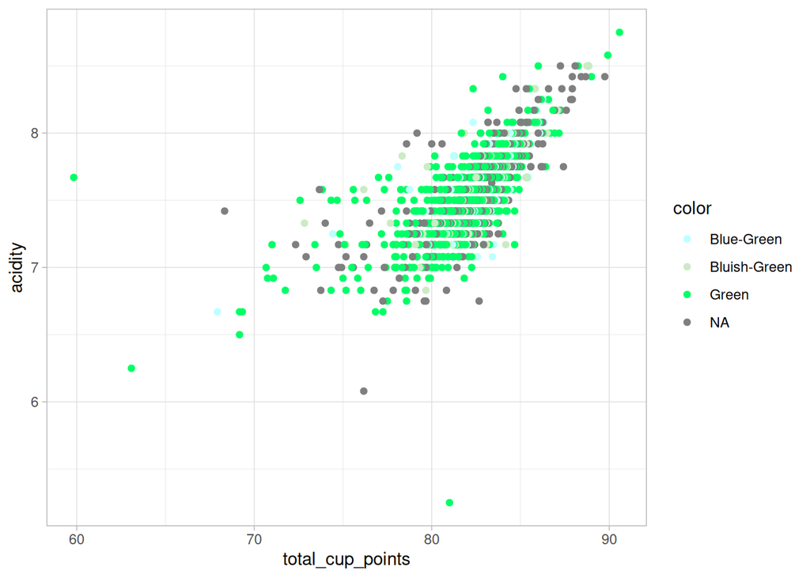

```r
# Tomaremos total_cup_points > 0 ya que hay un punto que modifica un poco la visualizacion
df_cafe_color2 |> filter(total_cup_points > 0) |>
  ggplot(aes(x = total_cup_points, y = acidity, color = color)) +
  geom_point() +
  # Agregamos los colores para la visualizacion
  scale_color_manual(values = c("Green" = "#00FF66",
                                "Bluish-Green" = "#CCEBC5",
                                "Blue-Green" = "#BFFFFF")) +
  theme_light()
```

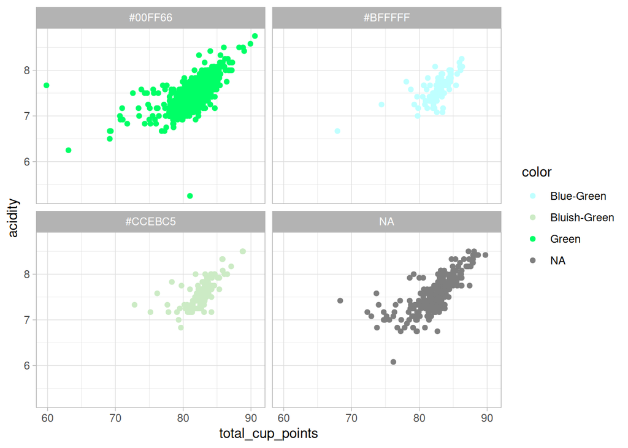

```r
df_cafe_color2 |> filter(total_cup_points > 0) |>
  ggplot(aes(x = total_cup_points, y = acidity, color = color)) +
  geom_point() +
  scale_color_manual(values = c("Green" = "#00FF66",
                                "Bluish-Green" = "#CCEBC5",
                                "Blue-Green" = "#BFFFFF")) +
  facet_wrap(~color2) +
  theme_light()
```

Sintaxis python

```python
# haciendo la columna de color2 en python
# Creamos un diccionario para despues mapear los colores a su respectivo cambio
colores = {"Green": "#00FF66", "Bluish-Green": "#CCEBC5", "Blue-Green": "#BFFFFF"}

# Creamos la nueva columna color2
# .map() busca el valor en el diccionario; si no existe, pone NaN
df_cafe['color2'] = df_cafe['color'].map(colores)

print(df_cafe[['color', 'color2']])
```

```
           color   color2
0          Green  #00FF66
1          Green  #00FF66
2            NaN      NaN
3          Green  #00FF66
4          Green  #00FF66
...          ...      ...
1334  Blue-Green  #BFFFFF
1335  Blue-Green  #BFFFFF
1336         NaN      NaN
1337       Green  #00FF66
1338         NaN      NaN

[1339 rows x 2 columns]
```

[figure not shown]

```python
# Tomamos total_cup_points > 0
df_filtrado = df_cafe[df_cafe["total_cup_points"] > 0]

# Creamos un diccionario para poder asignar los colores
colores_cafe = {"Green": "#00FF66","Bluish-Green": "#CCEBC5",
"Blue-Green": "#BFFFFF"}

# Cinfiguramos el grafico
plt.figure(figsize=(8, 8))
sns.scatterplot(data=df_filtrado,
                x="acidity",
                y="total_cup_points",
                hue="color",
                palette=colores_cafe)

# Agregamos unas etiquetas
plt.xlabel("Total Cup Points")
plt.ylabel("Acidity")
plt.title("Relación entre Puntaje y Acidez por Color del Café")

plt.show()
```

En ambas visualizaciones podemos ver que hay una correlación positiva entre las variables “total_cup_point” y “acidity”, es decir, a mayor puntos todales mayor es la acidez del cafe. Además pordemos ver que el color verde predomina en los datos registrados.

# Actividades 7 y 8

#### Elabore una visualización de densidad con {ggplot2} de la variable bag_weight2 diferenciando a los valores de species.

Observamos las especies de cafe.

```r
unique(coffee$species) #observar las especies
```

```
[1] "Arabica" "Robusta"
```

- Arabica: suele representar cafes de mayor calidad, especialidad y origen.
- Robusta: representa el cafe de consumo comercial.

Damos un vistazo a estas dos columnas:

```r
df_mod %>%
  select( bag_weight, bag_weight2)
```

```
     bag_weight  bag_weight2
1         60 kg    60.000000
2         60 kg    60.000000
3             1     1.000000
4         60 kg    60.000000
5         60 kg    60.000000
6         30 kg    30.000000
7         69 kg    69.000000
8         60 kg    60.000000
9         60 kg    60.000000
10        60 kg    60.000000
11        60 kg    60.000000
12         1 kg     1.000000
13         1 kg     1.000000
14            1     1.000000
```

[output cut: 1325 more lines]

```r
summary(df_mod$bag_weight2)
```

```
    Min.  1st Qu.   Median     Mean  3rd Qu.     Max.
    0.00     1.00    45.36   178.75    69.00 19200.00
```

Por lo tanto, para obtener una visualizacion mas clara y representativa en la grafica de densidad, se van a considerar unicamente los valores menores a 300, excluyendo asi el outlier de 19200.

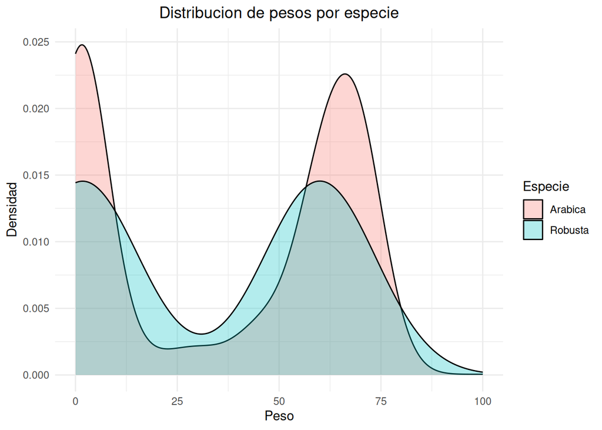

```r
df_mod %>%
  filter(bag_weight2 < 300) %>% #nos quedamos solo con pesos menores a 300
  ggplot(aes(x = bag_weight2, fill = species)) +

    geom_density(alpha = 0.3) +
    theme_minimal() +

    labs(title = "Distribucion de pesos por especie",
      x = "Peso",
      y = "Densidad",
      fill = "Especie") +

  theme(plot.title = element_text(hjust = 0.5))
```

- ambas especies presentan una distribucion bimodal, ya que se observan dos picos principales de densidad
- los datos provienen de dos poblaciones diferentes mezclados en uno solo, mostrando dos grupos, bolsas de pesan entre 2- 10, que pueden representar ventan por menudeo o pruebas
- y bolsas que pesan entre 60-75, que pueden representar las ventar por mayoreo o exportacion
- hay mas bolsas de Robusta con pesos intermedios-30, 40, 50 que en la variedad Arabica
- el peso no depende de la especie sino del canal de comercializacion
- la especie Arabica muestra una alta estandarizacion en sus procesos logisticos por sus picos muy definidos
- la especie Robusta presenta una mayor variabilidad en los pesos de sus bolsas
- aprox en el peso 80, la densidad disminuye rapidamente en ambas especies, por lo que existen pocos registros con pesos altos, aunque no consideremos el valor maximo, todavia quedan algunos bolsas pesadas, outliers moderados que son inusuales pero posibles

Ahora veamos como se ve en Python, observamos bag_weight y bag_weight2 para comparar valores originales y convertidos.

```r
library(reticulate)
py_run_string("
import pandas as pd
import matplotlib.pyplot as plt
df =r.df_mod
datos = pd.read_csv('coffee_ratings.csv')
")
```

```r
py_run_string("print(df[['bag_weight', 'bag_weight2']])")
```

```
     bag_weight  bag_weight2
0         60 kg     60.00000
1         60 kg     60.00000
2             1      1.00000
3         60 kg     60.00000
4         60 kg     60.00000
...         ...          ...
1334       2 kg      2.00000
1335       2 kg      2.00000
1336       1 kg      1.00000
1337      5 lbs      2.26796
1338      5 lbs      2.26796

[1339 rows x 2 columns]
```

```r
py_run_string("print(df['bag_weight2'].describe())")
```

```
count     1339.000000
mean       178.746661
std       1523.698359
min          0.000000
25%          1.000000
50%         45.359200
75%         69.000000
max      19200.000000
Name: bag_weight2, dtype: float64
```

- 19200 es un valor atipico extremadamente grande comparado con el resto de los datos.
- eliminar pesos exageradamente altos para que la visualizacion represente mejor el comportamiento tipico de los datos es la mejor opcion.

```r
py_run_string("print(df['species'].value_counts())")
```

```
species
Arabica    1311
Robusta      28
Name: count, dtype: int64
```

- al tener 28 registros las visualizacion estara dominada por Arabica

Ajusta la normalizacion `common_norm=False` en la visualizacion podemos comparar mejor.

```r
library(reticulate)

py_run_string
```

```
function (code, local = FALSE, convert = TRUE)
{
    invisible(py_run_string_impl(code, local, convert))
}
<bytecode: 0x61dbaf45a148>
<environment: namespace:reticulate>
```

```r
library(reticulate)

py_run_string("
import matplotlib
matplotlib.use('Agg')
import matplotlib.pyplot as plt
import seaborn as sns
import pandas as pd

df = r.df_mod  # Si df_mod ya existe en un chunk de R arriba

datos_filtrados = df[df['bag_weight2'] < 300]

plt.figure(figsize=(8,5))

sns.kdeplot(
  data=datos_filtrados,
  x='bag_weight2',
  hue='species',
  fill=True,
  alpha=0.3,
  common_norm=False,
  bw_adjust=0.8
)

plt.title('Distribucion de pesos por especie')  # Una sola comilla al final
plt.xlabel('Peso')
plt.ylabel('Densidad')
plt.show()
")
```

[output not shown]

- presenta un fuerte desbalance entre especies, ya que la variedad Arabica concentra casi la totalidad de las observaciones
- presenta una estructura bimodal dominada principalmente por la especie Arabica
- con una cantidad muy reducida de registros de Robusta, limita la capacidad de realizar comparaciones entre las especies
- la presencia de picos de densidad en Arabica indica una posible estandarizacion en ciertos pesos de las bolsas, mientras que los pocos registros de pesos elevados corresponden a casos poco frecuentes pero posibles

# Actividad 8: Elabore una visualización que relacione el año/mes de expiración con el total_cup_points sólo de los granos mexicanos, brasileños, colombianos y guatemaltecos.

```r
head(coffee$expiration) #primeros valores
```

```
[1] "April 3rd, 2016"     "April 3rd, 2016"     "May 31st, 2011"
[4] "March 25th, 2016"    "April 3rd, 2016"     "September 3rd, 2014"
```

- las fechas de expiracion se encuentran almacenadas en formato de texto, incluyendo el mes, dia y año
- es necesario convertir la variable a formato fecha para poder extraer correctamente el año y el mes

```r
library(lubridate)
datos <- coffee %>%
  mutate(fecha = mdy(expiration)) #permite convertir las fechas almacenadas como texto al formato de fecha

head(datos$fecha) #observamos la conversion de la fecha
```

```
[1] "2016-04-03" "2016-04-03" "2011-05-31" "2016-03-25" "2016-04-03"
[6] "2014-09-03"
```

Se creo una nueva variable llamada fecha a partir de la columna `expiration` y de la fecha solo se extra el mes y año.

```r
datos <- datos %>%
  mutate( year= year(fecha), #extraer año de la fecha
    mes = month(fecha, label = TRUE)) #extraer mes abreviado
```

Se filtra unicamente los paises que nos interesan, en este caso Mexico, Brasil, Colombia y Guatemala

```r
paises <- c("Mexico", "Brazil", "Colombia", "Guatemala")

datos_filtrados <- datos %>%
  filter(country_of_origin %in% paises) #filtramos solo esos paises

datos_filtrados %>%
  select("country_of_origin", "mes", "year")
```

```
# A tibble: 732 × 3
   country_of_origin mes    year
   <chr>             <ord> <dbl>
 1 Guatemala         may    2011
 2 Brazil            sep    2014
 3 Mexico            jul    2013
 4 Brazil            dic    2012
 5 Brazil            dic    2012
 6 Brazil            ene    2012
 7 Brazil            ene    2012
 8 Brazil            dic    2012
 9 Colombia          mar    2015
10 Guatemala         may    2017
# ℹ 722 more rows
```

```r
datos_filtrados %>%
  count(year) #cuenta los registros por año
```

```
# A tibble: 9 × 2
   year     n
  <dbl> <int>
1  2011     9
2  2012    54
3  2013   268
4  2014    91
5  2015   104
6  2016    74
7  2017    59
8  2018    71
9  2019     2
```

- existen años con muchos registros, como 2013 con 268 observaciones, mientras que otros presentan muy pocos datos, como 2011 con 9 registros y 2019 con solo 2
- es por ello que no vamos a considerar la variable mes, si se incluyera la variable mensual, los datos quedarian demasiado fragmentados, generando meses con muy pocas observaciones e incluso sin registros, lo que dificultaria identificar patrones claros y realizar comparaciones

boxplot representa una de las mejores opciones de visualizacion, ya que permitira comparar la distribucion de `total_cup_points` entre distintos años, detectar posibles valores atipicos y analizar diferencias entre grupos aun cuando la cantidad de registros por año no sea la misma

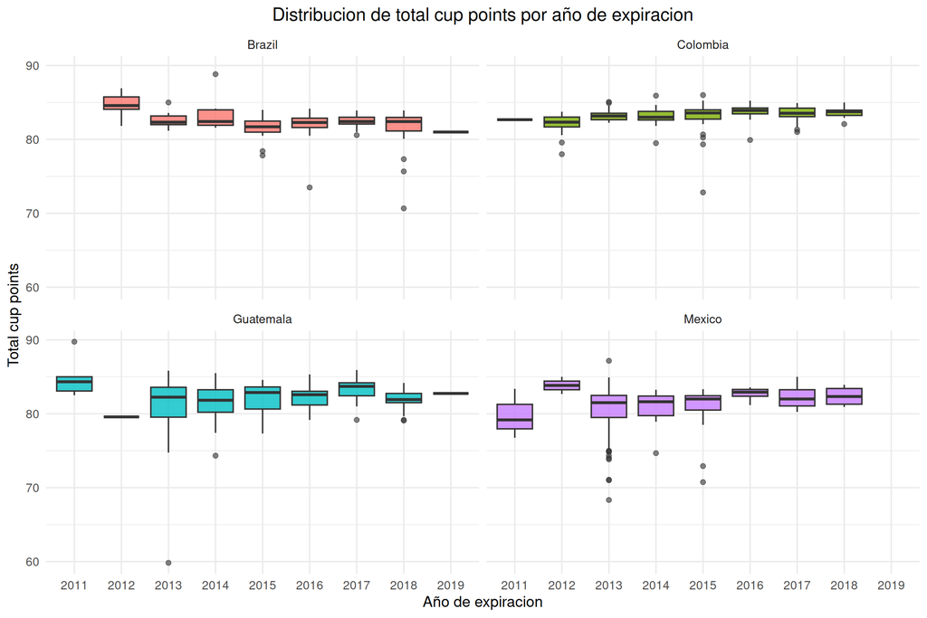

```r
ggplot(datos_filtrados,
       aes(x = factor(year), #año como categorias
           y = total_cup_points,
           fill = country_of_origin)) +

  geom_boxplot(alpha = 0.8, outlier.alpha = 0.6) + #valores atipicos visibles

  facet_wrap(~ country_of_origin) + #grafica por pais

  theme_minimal(base_size = 14) +

  labs(title = "Distribucion de total cup points por año de expiracion",
    x = "Año de expiracion",
    y = "Total cup points") +

  theme(legend.position = "none", plot.title = element_text(hjust = 0.5))
```

Visualizamos en python:

```r
library(reticulate)
py_run_string("
import pandas as pd
import matplotlib.pyplot as plt

datos = pd.read_csv('coffee_ratings.csv')
")
```

Observamos como estan almacenadas las fechas originalmente

```r
py_run_string("print(datos['expiration'].head())")
```

```
0     April 3rd, 2016
1     April 3rd, 2016
2      May 31st, 2011
3    March 25th, 2016
4     April 3rd, 2016
Name: expiration, dtype: str
```

Convertimos dichos valores a formato fecha

```r
py_run_string("
datos['fecha'] = pd.to_datetime(datos['expiration'], format='mixed', errors='coerce')
print(datos['fecha'].head())")
```

```
0   2016-04-03
1   2016-04-03
2   2011-05-31
3   2016-03-25
4   2016-04-03
Name: fecha, dtype: datetime64[us]
```

Ahora se va a extrae unicamente el año y se almacena en una nueva columna llamada year. Solo se utiliza la variable year, si no dificultaria la interpretacion visual, filtrando los paises.

```r
py_run_string("
datos['year'] = datos['fecha'].dt.year

paises = ['Mexico', 'Brazil', 'Colombia', 'Guatemala']
datos_filtrados = datos[ datos['country_of_origin'].isin(paises)]")
```

Visualizamos en una grafica.

```r
py_run_string("fig, axes = plt.subplots(1, 4, figsize=(15, 7), sharey=True) #creamos la figura

#ciclo para graficar cada pais
for i, pais in enumerate(paises):
    df_pais = datos_filtrados[datos_filtrados['country_of_origin'] == pais]

    años = sorted(df_pais['year'].unique()) #agrupar datos por año
    datos_boxplot = [df_pais[df_pais['year'] == a]['total_cup_points'].dropna() for a in años]

    mis_colores = ['skyblue', 'purple', 'lightgreen', 'gold']
    bp = axes[i].boxplot(datos_boxplot, patch_artist=True, labels=años, widths=0.6)
    for box in bp['boxes']:
        box.set(facecolor=mis_colores[i], edgecolor='black')

    #titulos y rotacion
    axes[i].set_title(pais)
    axes[i].tick_params(axis='x', rotation=90)
    axes[i].grid(axis='y', linestyle='--', alpha=0.3)

axes[0].set_ylabel('Total Cup Points')
fig.suptitle('Distribucion de Total Cup Points por año de expiracion', fontsize=14)

plt.subplots_adjust(left=0.08, right=0.95, top=0.88, bottom=0.15, wspace=0.3)
plt.show()")
```

[output not shown]

# Actividad 9 y 10

Se tiene una visualización con {ggplot2} que relacione el mes de expiración con el `altitude_mean_meters`, `altitude_low_meters` y `altitude_high_meters` sólo de los granos mexicanos, brasileños, colombianos y guatemaltecos de los años de expiración 2016 y 2017. Se tiene una visualización con {ggplot2} que relacione el `aftertaste`, `acidity`, `body` y `species` en un mismo canvas.

```r
install.packages("sqldf")
```

```r
library(DBI)
library(dbplyr)
library(dplyr)
library(RSQLite)
library(sqldf)
library(readr)
library(lubridate)

library(tidyr)
library(ggplot2)

library(reticulate)
```

###### OJO ESTE CHUNK VIENE EN LA PARTE ANTERIOR

```r
#################################### OJO ESTA PARTE NO ES NECESARIA ####################################
#################################### ESTÁ EN LA PREGUNTA ANTERIOR ####################################
coffee <- readr::read_csv("coffee_ratings.csv")
datos <- coffee %>%
  mutate(fecha = mdy(expiration)) #permite convertir las fechas almacenadas como texto al formato de fecha

datos <- datos %>%
  mutate( year= year(fecha), #extraer año de la fecha
    mes = month(fecha, label = TRUE)) #extraer mes abreviado
```

Actividad 9: Elabore una visualización con ggplot2 que relacione el mes de expiración con el altitude_mean_meters, altitude_low_meters y altitude_high_meters sólo de los granos mexicanos, brasileños, colombianos y guatemaltecos de los años de expiración 2016 y 2017.

```r
# Filtrando por País y año de expiracion
df_plot <- datos %>%
  filter(
    country_of_origin %in% c("Mexico", "Brazil", "Colombia", "Guatemala"),
    year %in% c(2016, 2017)
  )
```

Se crea una gráfica de barras que meustra el promedio de altitud (media baja y alta) por mes de expiración. - La altura de las barras representa el promedio de altura media. - Las lineas muestran el promedio de altitud baja y alta.

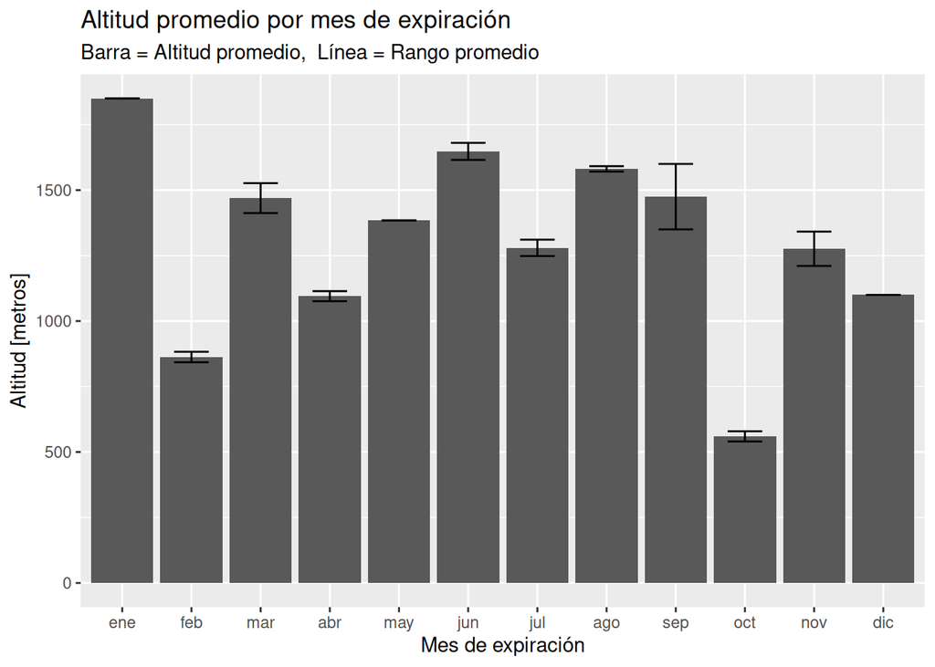

```r
# Calculando promedio de altiud low, mean y high por mes de expiracion
df_plot <- df_plot %>%
  group_by(mes) %>%
  summarise(
    promedio_mean = mean(altitude_mean_meters, na.rm = TRUE),
    promedio_low = mean(altitude_low_meters, na.rm = TRUE),
    promedio_high = mean(altitude_high_meters, na.rm = TRUE)
  )

# Creando gráfica de barras
# - En el eje X, mes de expiracion
# - En el eje Y, el promedio de la altura promedio es la altuira de la barra,
#   las "barras de error" muestran el promedio del low y high altitude.

# Creando barras y "barras de error"
ggplot(df_plot, aes(x = mes, y = promedio_mean)) +
  geom_col() +
  geom_errorbar(aes(
    ymin = promedio_low,
    ymax = promedio_high
  ),
  width = 0.5
  ) +
  # Agregando titulos y ejes
  labs(
    title = "Altitud promedio por mes de expiración",
    subtitle = "Barra = Altitud promedio,  Línea = Rango promedio",
    x = "Mes de expiración",
    y = "Altitud [metros]"
  )
```

Graficando en Python

Esta gráfica se recomienda correr el .qmd en rstudio o positcloud, ya que la visualización la hace en el navegador de internet, siendo la gráfica de altitud promedio y mes de expiración:

```r
library(reticulate)
py_require("plotly")
```

```r
library(reticulate)

py_run_string('
import pandas as pd
import plotly.express as px
import plotly.graph_objects as go


datos = pd.read_csv("coffee_ratings.csv")

df_plot = datos.copy()

# Convirtiendo a expiration_date en fecha
df_plot["expiration_date"] = pd.to_datetime(datos["expiration"], format="mixed", errors="coerce")

# Creando columna de anno y mes de expiacion
df_plot["expiration_year"] = df_plot["expiration_date"].dt.year
df_plot["expiration_month"] = df_plot["expiration_date"].dt.month_name()

# Filtrando por pais y anno de expiracion
df_plot = df_plot[
    (df_plot["country_of_origin"].isin(["Mexico", "Brazil", "Colombia", "Guatemala"])) &
    (df_plot["expiration_year"].isin([2016, 2017]))
]

# Resumen por mes de expiracion
df_plot = df_plot.groupby("expiration_month", as_index=False).agg(
    promedio_mean=("altitude_mean_meters", "mean"),
    promedio_low=("altitude_low_meters", "mean"),
    promedio_high=("altitude_high_meters", "mean")
)

# expiration_month se convierte en variable categorica para graficar en orden
orden_meses = [
    "January", "February", "March", "April", "May", "June",
    "July", "August", "September", "October", "November", "December"
]

df_plot["expiration_month"] = pd.Categorical(
    df_plot["expiration_month"],
    categories=orden_meses,
    ordered=True
)

# Se ordena la tabla por expiration_month
df_plot = df_plot.sort_values("expiration_month")

# creando grafica de barras
fig1 = go.Figure()

fig1.add_trace(
    go.Bar(
        x=df_plot["expiration_month"],
        y=df_plot["promedio_mean"],
        # Agregando "barra de error"
        error_y=dict(
            type="data",
            symmetric=False,
            array=df_plot["promedio_high"] - df_plot["promedio_mean"],
            arrayminus=df_plot["promedio_mean"] - df_plot["promedio_low"]
        ),
        name="Altitud promedio"
    )
)
# Aggregando título
fig1.update_layout(
    title=dict(
        text="Altitud promedio por mes de expiración<br>Barra = Altitud promedio, Línea = Rango promedio"
    ),
    xaxis_title="Mes de expiración",
    yaxis_title="Altitud [metros]"
)

fig1.show()
              ')
```

Actividad 10: Elabore una visualización con ggplot2 que relacione el `aftertaste`, `acidity`, `body` y `species` en un mismo canvas.

Se crea un boxplot con los puntajes de aftertaste, acidity y body según la especie.

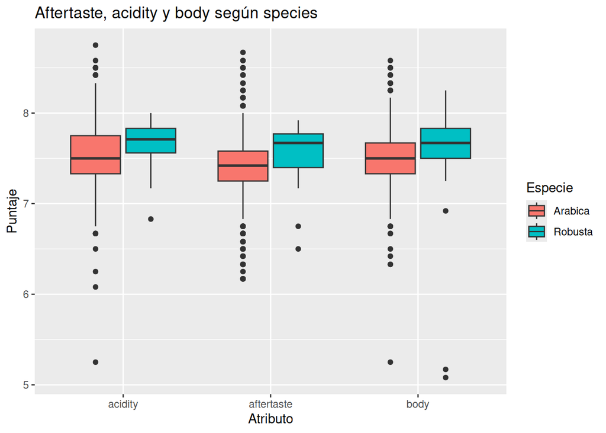

```r
library(dplyr)
library(tidyr)
library(ggplot2)

# Filtrando datos con acides, aftertaste y body = 0 para poder observar mejor la gráfica
df_plot <- datos %>%
  filter(
    acidity != 0,
    aftertaste!=0 ,
    body!=0
  )
# Cambiando formato de tabla para poder graficar
df_plot <- df_plot %>%
  pivot_longer(
    cols = c(aftertaste, acidity, body),
    names_to = "atributo",
    values_to = "puntaje"
  )
# Graficando bocplot en el Eje x los distintos puntajes
ggplot(df_plot, aes(x = atributo, y = puntaje, fill = species)) +
  geom_boxplot() +
  labs(
    title = "Aftertaste, acidity y body según species",
    x = "Atributo",
    y = "Puntaje",
    fill = "Especie"
  )
```

- Graficando en Python:

Misma recomendación que la gráfica de expiración promedio, correr directo el .qmd en positcloud o rstudio, ya que la visualización la manda al navegador, siendo la gráfica de compración de atributos por especie:

```r
py_run_string('
df_plot = datos[
    ["species", "aftertaste", "acidity", "body"]
].dropna()

#Quitando datos con puntajes 0 para poder visualizar mejor el boxplot
df_plot= df_plot[ (df_plot.aftertaste!= 0) | (df_plot.acidity!= 0) | (df_plot.body!= 0)]


# Cambiando formato para poder graficar
df_plot = df_plot.melt(
    id_vars="species",
    value_vars=["aftertaste", "acidity", "body"],
    var_name="atributo",
    value_name="puntaje"
)

# Plotly Boxplot
fig2 = px.box(
    df_plot,
    x="atributo",
    y="puntaje",
    color="species",
    title="Comparación de atributos sensoriales por especie"
)

# Ejes
fig2.update_layout(
    xaxis_title="Atributo sensorial",
    yaxis_title="Puntaje"
)

fig2.show()
              ')
```